# InVivoStat Single Measure Parametric Analysis

## Response

The Resp 1 response is currently being analysed by the Single Measures Parametric Analysis module.The response has been Square Root transformed prior to analysis.

## Scatterplot of the raw data (on the Square Root scale)

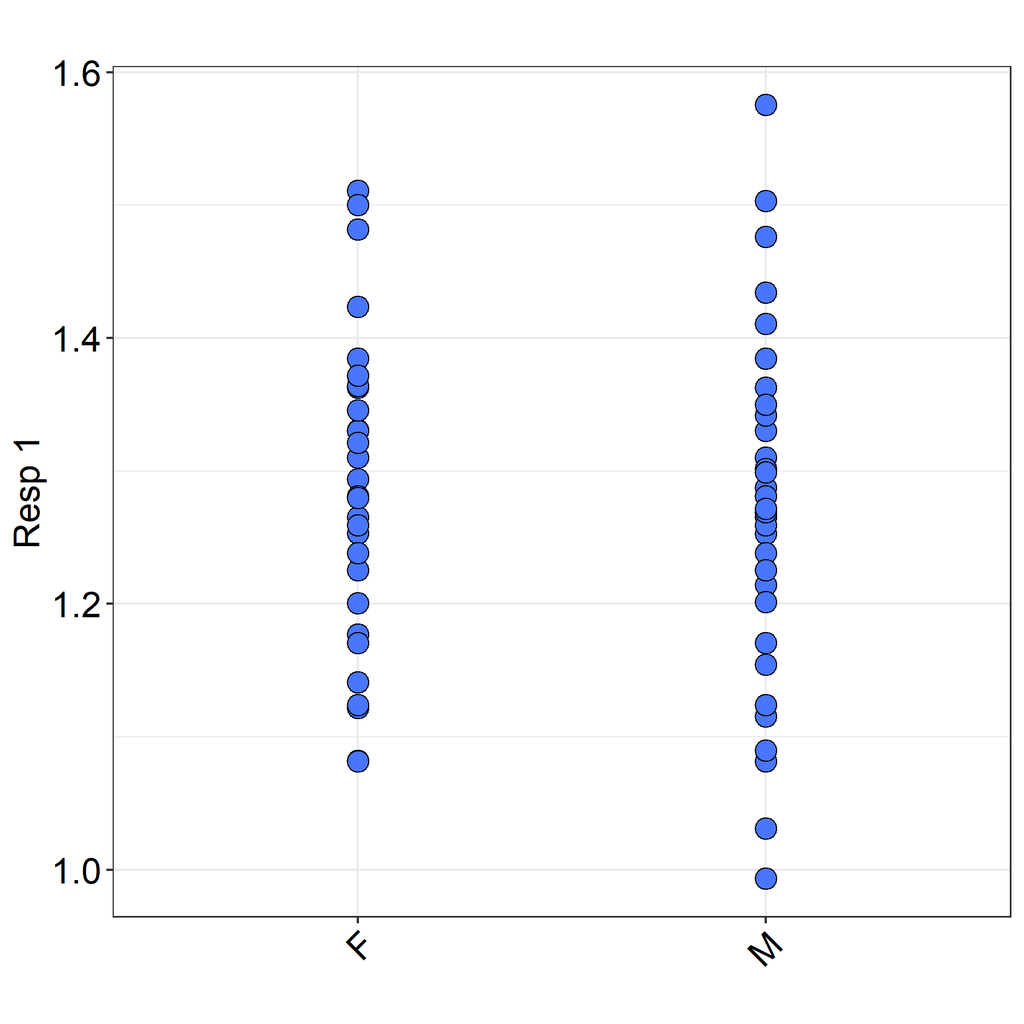

Tip: Use this plot to identify possible outliers.

## Analysis of variance (ANOVA) table

| Effect | Sums of squares | Degrees of freedom | Mean square | F-value | p-value |
| --- | --- | --- | --- | --- | --- |
| Blo ck1 | 0.001 | 1 | 0.001 | 0.05 | 0.8289 |
| Blo ck2 | 0.020 | 2 | 0.010 | 0.68 | 0.5089 |
| Treat2 | 0.000 | 1 | 0.000 | 0.03 | 0.8662 |
| Residual | 1.068 | 73 | 0.015 |  |  |

Comment: ANOVA table calculated using a Type III model fit, see Armitage et al. (2001).

Conclusion. : There are no statistically significant overall differences between the levels of any of the terms in the ANOVA table.

Tip: While it is a good idea to consider the overall tests in the ANOVA table, we should not rely on them when deciding whether or not to make pairwise comparisons.

## Diagnostic plots

### Residuals vs. predicted plot

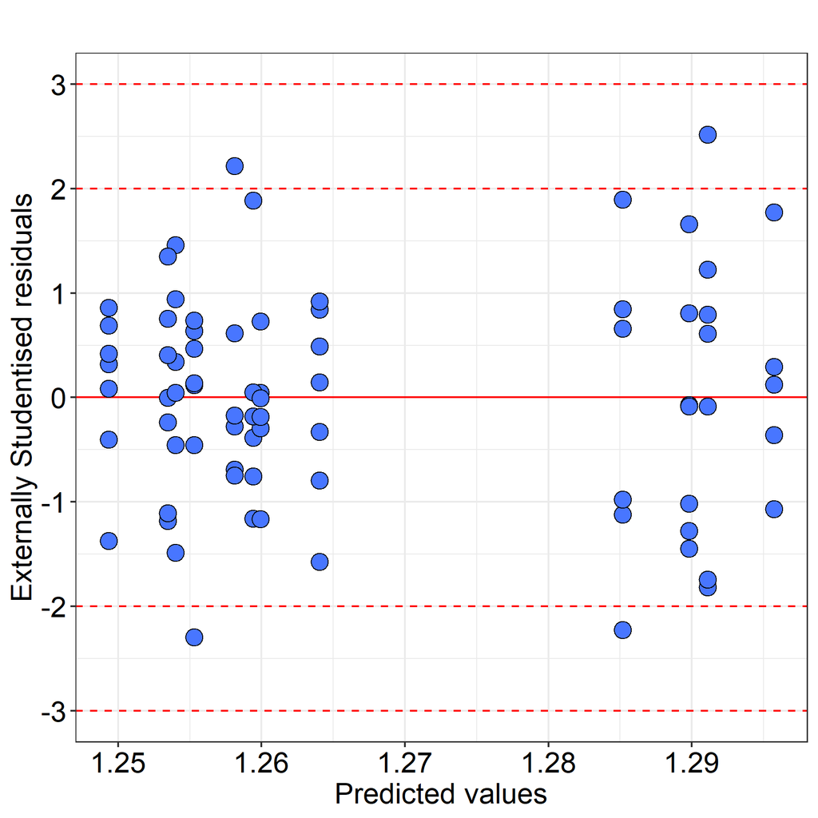

Tip: On this plot look to see if the spread of the points increases as the predicted values increase. If so the response may need transforming.

Tip: Any observation with a residual less than -3 or greater than 3 (SD) should be investigated as a possible outlier.

### Normal probability plot

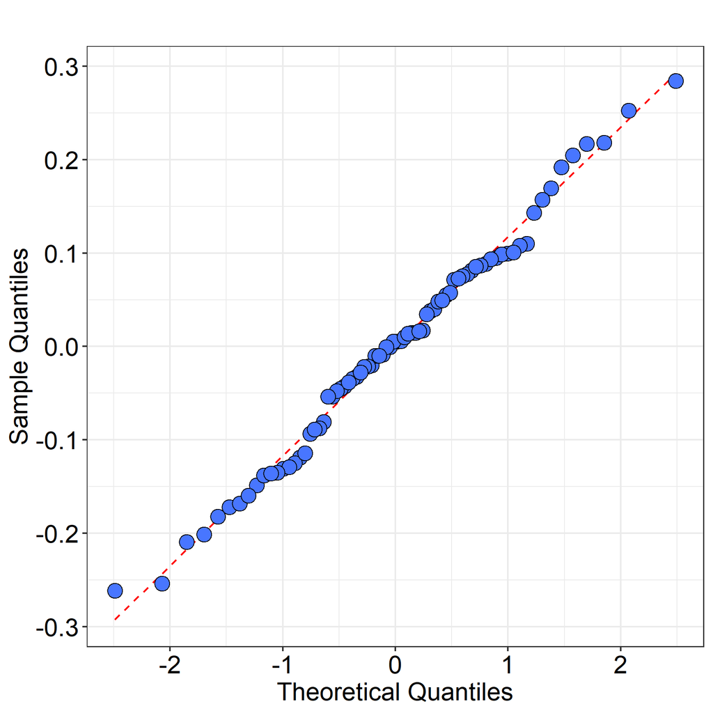

Tip: Check that the points lie along the dotted line. If not then the data may be non-normally distributed.

## Plot of the least square (predicted) means with 95% confidence intervals

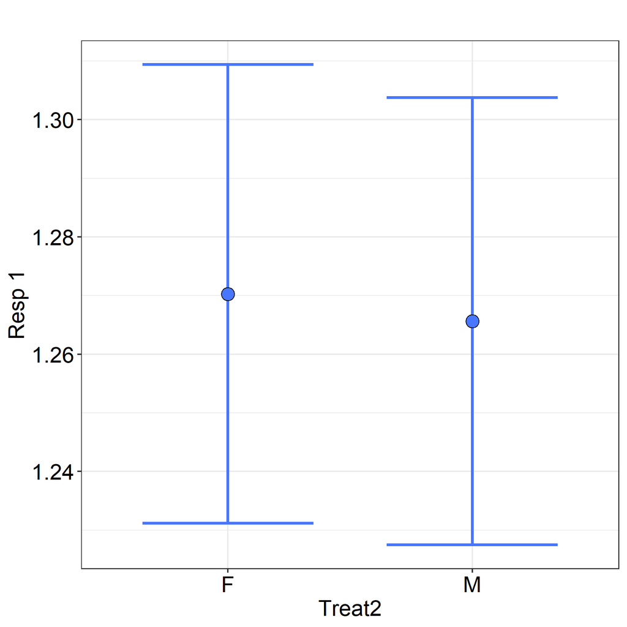

## Table of the least square (predicted) means with 95% confidence intervals

| Mean ID | Treat2 | Mean | Lower 95% CI | Upper 95% CI |
| --- | --- | --- | --- | --- |
| 1 | F | 1.270 | 1.231 | 1.309 |
| 2 | M | 1.266 | 1.228 | 1.304 |